# Dragon Ball Unsupervised Learning

## Unsupervised Learning Ideas

Character Clustering

- Discover hidden archetypes such as Tactical Fighters vs. Energy Blasters or Speed-based vs. Power-based combatants.
  - Fighting style (Ki Blast, Melee Combat, Special Attack)
  - Power Level and Speed Score
  - Transformation Type (Super Saiyan, Fusion, etc.)

Anomaly Detection

- Find overpowered characters or those with unusual abilities.
  - Identify outliers in Power Score or Transformations.
  - Detect characters with extremely high battle efficiency compared to other
  - Use Isolation Forest or Local Outlier Factor (LOF) to spot anomalies.

Dimensionality Reduction for Visualization

- Understand how characters group together based on battle abilities.
  - Use PCA (Principal Component Analysis) or t-SNE (t-Distributed Stochastic Neighbor Embedding) to visualize relationships between different characters.

Association Rule Mining (Apriori / FP-Growth)

- Discover common move combinations or transformation patterns.
- Identify relationships between fighting techniques (Ki Blasts, Special Attacks) and transformation states.

## Objective

**Selected Project**: Character Clustering using Power Level, Speed, and Transformations

## Data Source

- [1 EDA](https://colab.research.google.com/drive/11_RHgukIdfJhYBmV1efLdg5AxEUDSQn3#scrollTo=xUq8dmSpwnP2)

## Data Dictionary

- data
  - Name
  - Race
  - Gender
  - Power Level
  - Ki Blast
  - Melee Combat
  - Speed
  - Special Attack
  - Transformation
  - Speed_Original
  - Speed_Score
  - Normalized_Power
  - Power_Score
  - Meta

## Importing Libraries and the Dataset

```python
# Mounting the drive
from google.colab import drive
drive.mount('/content/drive')
```

```python
# Used to ignore the warning given as output of the code
import warnings                                       # Ignore the warning given as output of the code
warnings.filterwarnings('ignore')

# Basic libraries of python for numeric and dataframe computations
import numpy as np                                    # Basic libraries numeric and dataframe computations
import pandas as pd

# Import Matplotlib the Basic library for data visualization
# Import seaborn - Slightly advanced library for data visualization
import matplotlib.pyplot as plt                       # Basic visualization library
import seaborn as sns

# Import the required library to compute the cosine similarity between two vectors


# Import defaultdict from collections A dictionary output that does not raise a key error
from collections import defaultdict                   # A dictionary output that does not raise a key error
```

## Load the Dataset

```python
# Loading the ratings dataset
# Load only selected columns directly
columns_to_keep = ['Race', 'Power Level', 'Power Level', 'Speed', 'Transformation'] # Power Level, Speed, and Transformations
data = pd.read_csv('/content/drive/MyDrive/My DS DA/Dragon Ball Z/data.csv', usecols=columns_to_keep)
```

```python
df = data.copy()
```

## Data Overview

```python
data.sample(5)
```

|  | Race | Power Level | Speed | Transformation |
| --- | --- | --- | --- | --- |
| 65 | Human | 50 | 1 | - |
| 38 | Alien | 120000 | 3 | Transformation |
| 19 | Demon | 6500 | 3 | Majin Form |
| 54 | Android | 8000 | 3 | - |
| 64 | Human | 10 | 1 | - |

```python
data.info()
```

```
<class 'pandas.core.frame.DataFrame'>
RangeIndex: 68 entries, 0 to 67
Data columns (total 4 columns):
 #   Column          Non-Null Count  Dtype
---  ------          --------------  -----
 0   Race            68 non-null     object
 1   Power Level     68 non-null     int64
 2   Speed           68 non-null     int64
 3   Transformation  68 non-null     object
dtypes: int64(2), object(2)
memory usage: 2.3+ KB
```

```python
transformation_counts = data['Transformation'].value_counts()
transformation_percentages = data['Transformation'].value_counts(normalize=True) * 100

# Combine both into a single DataFrame
transformation_summary = pd.DataFrame({'Count': transformation_counts, 'Percentage': transformation_percentages.round(2)})
transformation_summary
```

| Transformation | Count | Percentage |
| --- | --- | --- |
| - | 43 | 63.24 |
| Transformation | 10 | 14.71 |
| Super Saiyan | 4 | 5.88 |
| Majin Form | 3 | 4.41 |
| Merge with Piccolo | 2 | 2.94 |
| Fuse with Kami | 1 | 1.47 |
| Super Saiyan 2 | 1 | 1.47 |
| Perfect Form | 1 | 1.47 |
| Final Form | 1 | 1.47 |
| Various Forms | 1 | 1.47 |
| Absorption | 1 | 1.47 |

- More than half of transformations is missing
- some characters may not have transformations

```python
data.shape
```

```
(68, 4)
```

```python
data.columns.to_list()
```

```
['Race', 'Power Level', 'Speed', 'Transformation']
```

```python
data.isnull().sum()
```

|  | 0 |
| --- | --- |
| Race | 0 |
| Power Level | 0 |
| Speed | 0 |
| Transformation | 0 |

**dtype:** int64

```python
# data.duplicated().sum()
```

```python
data.info()
```

```
<class 'pandas.core.frame.DataFrame'>
RangeIndex: 68 entries, 0 to 67
Data columns (total 4 columns):
 #   Column          Non-Null Count  Dtype
---  ------          --------------  -----
 0   Race            68 non-null     object
 1   Power Level     68 non-null     int64
 2   Speed           68 non-null     int64
 3   Transformation  68 non-null     object
dtypes: int64(2), object(2)
memory usage: 2.3+ KB
```

## Data Preprocessing

- Transformation column needs to be encoded
- options
  - One-Hot Encoding (OHE)
    - If the number of unique transformations is low, One-Hot Encoding (OHE) is better since it creates binary columns.
    - Types
      - Ordinal Encoding for Transformation Progression
        - Manually assign numeric values to transformations based on their power progression
      - One-Hot Encoding for Transformation Types
        - equal weight for all transformations
  - Label Encoding
    - If there are many unique transformations, Label Encoding may be better to reduce dimensionality.
  - Frequency Encoding
    - for categorical imbalance
  - Target Encoding
    - correlation with the target variable

```python
print(data['Transformation'].unique())
```

```
['Super Saiyan' 'Fuse with Kami' 'Super Saiyan 2' '-' 'Perfect Form'
 'Final Form' 'Various Forms' 'Majin Form' 'Merge with Piccolo'
 'Transformation' 'Absorption']
```

Encoding

- some transformations are in progression (e.g., Super Saiyan < Super Saiyan 2 < Final Form)

Define Race-Specific Transformations

```python
# Define race-specific transformations
transformation_race_map = {
    'Super Saiyan': ['Saiyan', 'Half-Saiyan'],
    'Super Saiyan 2': ['Saiyan', 'Half-Saiyan'],
    'Perfect Form': ['Bio-Android'],
    'Final Form': ['Frost Demon'],
    'Majin Form': ['Human', 'Saiyan', 'Majin'],
    'Absorption': ['Majin', 'Bio-Android'],
    'Merge with Piccolo': ['Namekian'],
    'Fuse with Kami': ['Namekian'],
    'Transformation': ['Various'],
    'Various Forms': ['Various'],
    '-': ['Various']  # No transformation
}
```

Create a New Column for Race Validation

```python
def check_valid_transformation(row):
    valid_races = transformation_race_map.get(row['Transformation'], ['Various'])
    return 1 if row['Race'] in valid_races else 0

# Apply to dataset
data['Valid_Transformation'] = data.apply(check_valid_transformation, axis=1)
```

```python
data['Valid_Transformation'].value_counts()
```

| Valid_Transformation | count |
| --- | --- |
| 0 | 56 |
| 1 | 12 |

**dtype:** int64

```python
data.head()
```

|  | Race | Power Level | Speed | Transformation | Valid_Transformation |
| --- | --- | --- | --- | --- | --- |
| 0 | Saiyan | 9000 | 3 | Super Saiyan | 1 |
| 1 | Saiyan | 8500 | 3 | Super Saiyan | 1 |
| 2 | Namekian | 8000 | 3 | Fuse with Kami | 1 |
| 3 | Half-Saiyan | 7500 | 3 | Super Saiyan 2 | 1 |
| 4 | Half-Saiyan | 7800 | 3 | Super Saiyan | 1 |

One-Hot Encoding for Race-Specific Transformations

```python
for transformation, races in transformation_race_map.items():
    data[transformation + '_Valid'] = data['Race'].apply(lambda x: 1 if x in races else 0)
```

```python
data.head()
```

|  | Race | Power Level | Speed | Transformation | Valid_Transformation | Super Saiyan_Valid | Super Saiyan 2_Valid | Perfect Form_Valid | Final Form_Valid | Majin Form_Valid | Absorption_Valid | Merge with Piccolo_Valid | Fuse with Kami_Valid | Transformation_Valid | Various Forms_Valid | -_Valid |
| --- | --- | --- | --- | --- | --- | --- | --- | --- | --- | --- | --- | --- | --- | --- | --- | --- |
| 0 | Saiyan | 9000 | 3 | Super Saiyan | 1 | 1 | 1 | 0 | 0 | 1 | 0 | 0 | 0 | 0 | 0 | 0 |
| 1 | Saiyan | 8500 | 3 | Super Saiyan | 1 | 1 | 1 | 0 | 0 | 1 | 0 | 0 | 0 | 0 | 0 | 0 |
| 2 | Namekian | 8000 | 3 | Fuse with Kami | 1 | 0 | 0 | 0 | 0 | 0 | 0 | 1 | 1 | 0 | 0 | 0 |
| 3 | Half-Saiyan | 7500 | 3 | Super Saiyan 2 | 1 | 1 | 1 | 0 | 0 | 0 | 0 | 0 | 0 | 0 | 0 | 0 |
| 4 | Half-Saiyan | 7800 | 3 | Super Saiyan | 1 | 1 | 1 | 0 | 0 | 0 | 0 | 0 | 0 | 0 | 0 | 0 |

```python
data.drop(columns = ['Race', 'Transformation'], inplace = True)
```

```python
data.head()
```

|  | Power Level | Speed | Valid_Transformation | Super Saiyan_Valid | Super Saiyan 2_Valid | Perfect Form_Valid | Final Form_Valid | Majin Form_Valid | Absorption_Valid | Merge with Piccolo_Valid | Fuse with Kami_Valid | Transformation_Valid | Various Forms_Valid | -_Valid |
| --- | --- | --- | --- | --- | --- | --- | --- | --- | --- | --- | --- | --- | --- | --- |
| 0 | 9000 | 3 | 1 | 1 | 1 | 0 | 0 | 1 | 0 | 0 | 0 | 0 | 0 | 0 |
| 1 | 8500 | 3 | 1 | 1 | 1 | 0 | 0 | 1 | 0 | 0 | 0 | 0 | 0 | 0 |
| 2 | 8000 | 3 | 1 | 0 | 0 | 0 | 0 | 0 | 0 | 1 | 1 | 0 | 0 | 0 |
| 3 | 7500 | 3 | 1 | 1 | 1 | 0 | 0 | 0 | 0 | 0 | 0 | 0 | 0 | 0 |
| 4 | 7800 | 3 | 1 | 1 | 1 | 0 | 0 | 0 | 0 | 0 | 0 | 0 | 0 | 0 |

```python
data.info()
```

```
<class 'pandas.core.frame.DataFrame'>
RangeIndex: 68 entries, 0 to 67
Data columns (total 14 columns):
 #   Column                    Non-Null Count  Dtype
---  ------                    --------------  -----
 0   Power Level               68 non-null     int64
 1   Speed                     68 non-null     int64
 2   Valid_Transformation      68 non-null     int64
 3   Super Saiyan_Valid        68 non-null     int64
 4   Super Saiyan 2_Valid      68 non-null     int64
 5   Perfect Form_Valid        68 non-null     int64
 6   Final Form_Valid          68 non-null     int64
 7   Majin Form_Valid          68 non-null     int64
 8   Absorption_Valid          68 non-null     int64
 9   Merge with Piccolo_Valid  68 non-null     int64
 10  Fuse with Kami_Valid      68 non-null     int64
 11  Transformation_Valid      68 non-null     int64
 12  Various Forms_Valid       68 non-null     int64
 13  -_Valid                   68 non-null     int64
dtypes: int64(14)
memory usage: 7.6 KB
```

```python
data.shape
```

```
(68, 14)
```

```python
# data.duplicated().sum()
```

```python
# data[data.duplicated]
```

```python
data.isnull().sum().sum()
```

```
0
```

```python
num_cols = data.select_dtypes(include=['number']).columns
num_cols
```

```
Index(['Power Level', 'Speed', 'Valid_Transformation', 'Super Saiyan_Valid',
       'Super Saiyan 2_Valid', 'Perfect Form_Valid', 'Final Form_Valid',
       'Majin Form_Valid', 'Absorption_Valid', 'Merge with Piccolo_Valid',
       'Fuse with Kami_Valid', 'Transformation_Valid', 'Various Forms_Valid',
       '-_Valid'],
      dtype='object')
```

## Dimensionality Reduction

### Scaling

#### Scaling Options

```python
from sklearn.preprocessing import (
    StandardScaler, MinMaxScaler, RobustScaler, MaxAbsScaler,
    PowerTransformer, QuantileTransformer, Normalizer
)

# 📌 Load dataset (Modify path if needed)
#file_path = "your_dataset.csv"  # Update with correct file
#data = pd.read_csv(file_path)

# 📌 Select numeric columns only
numeric_features = data.select_dtypes(include=['number']).dropna()

# 📌 Detect Outliers using IQR (Interquartile Range)
def detect_outliers(df):
    outlier_info = {}
    for column in df.columns:
        Q1 = df[column].quantile(0.25)
        Q3 = df[column].quantile(0.75)
        IQR = Q3 - Q1
        lower_bound = Q1 - 1.5 * IQR
        upper_bound = Q3 + 1.5 * IQR

        # Count outliers
        outlier_count = ((df[column] < lower_bound) | (df[column] > upper_bound)).sum()
        outlier_info[column] = outlier_count

    return outlier_info

outliers = detect_outliers(numeric_features)
outlier_df = pd.DataFrame.from_dict(outliers, orient='index', columns=['Outlier Count'])

# 📌 Check Skewness (to determine if transformation is needed)
skewness = numeric_features.skew()

# 📌 Scaling Options with All Variants
scalers = {
    "StandardScaler": StandardScaler(),
    "MinMaxScaler": MinMaxScaler(),
    "RobustScaler": RobustScaler(),
    "MaxAbsScaler": MaxAbsScaler(),
    "PowerTransformer (Yeo-Johnson)": PowerTransformer(method="yeo-johnson"),
    "PowerTransformer (Box-Cox)": PowerTransformer(method="box-cox"),
    "QuantileTransformer (Normal)": QuantileTransformer(output_distribution="normal"),
    "QuantileTransformer (Uniform)": QuantileTransformer(output_distribution="uniform"),
    "Normalizer (L1)": Normalizer(norm="l1"),
    "Normalizer (L2)": Normalizer(norm="l2"),
    "Normalizer (Max)": Normalizer(norm="max"),
}

scaler_results = {}

# 📌 Try all scalers & transformations
for scaler_name, scaler in scalers.items():
    try:
        transformed_data = scaler.fit_transform(numeric_features)
        transformed_df = pd.DataFrame(transformed_data, columns=numeric_features.columns, index=numeric_features.index)

        # Calculate variance after scaling (Higher is better)
        cumulative_variance = transformed_df.var().sum()
        scaler_results[scaler_name] = cumulative_variance

    except Exception as e:
        print(f"❌ Error with {scaler_name}: {e}")

# 📌 Convert results to DataFrame and Rank
scaler_rank_df = pd.DataFrame(list(scaler_results.items()), columns=['Scaler', 'Cumulative Variance'])
scaler_rank_df = scaler_rank_df.sort_values(by="Cumulative Variance", ascending=False)

# 📌 Pick the best scaler based on variance ranking
best_scaler_name = scaler_rank_df.iloc[0]["Scaler"]
best_scaler = scalers[best_scaler_name]
scaled_data = best_scaler.fit_transform(numeric_features)

# 📌 Convert Scaled Data to DataFrame
scaled_df = pd.DataFrame(scaled_data, columns=numeric_features.columns, index=numeric_features.index)

# 📌 Save the scaled dataset
scaled_df.to_csv("scaled_dataset.csv", index=False)

# 📌 Explain Selection
explanations = {
    "MinMaxScaler": "Scales data between [0,1]. Used in Unsupervised Learning & Deep Learning but NOT recommended for outliers.",
    "StandardScaler": "Standardizes data to mean=0, variance=1. Recommended for Unsupervised Learning & Deep Learning. Works well with outliers.",
    "RobustScaler": "Uses median and IQR. Best choice for handling outliers in both Unsupervised and Supervised Learning.",
    "MaxAbsScaler": "Scales data between [-1,1]. Used for sparse data, not generally needed for typical datasets.",
    "PowerTransformer (Yeo-Johnson)": "Transforms data to be more Gaussian-like. Good for skewed data in Regression & Classification.",
    "PowerTransformer (Box-Cox)": "Similar to Yeo-Johnson but works only with strictly positive values. Reduces skewness.",
    "QuantileTransformer (Normal)": "Maps data to a normal distribution. Works well when distribution is unknown.",
    "QuantileTransformer (Uniform)": "Maps data to a uniform distribution. Useful for highly irregular distributions.",
    "Normalizer (L1)": "Normalizes each row by L1 norm. Good for text-based or sparse datasets.",
    "Normalizer (L2)": "Normalizes each row by L2 norm. Often used in clustering tasks.",
    "Normalizer (Max)": "Normalizes each row by its maximum absolute value. Good for text and sparse data."
}

# 📌 Print Summary
print("\n📊 Scaler Rankings:")
print(scaler_rank_df)

print(f"\n🏆 Best Scaler Chosen: {best_scaler_name}")
print(f"📌 Reason: {explanations.get(best_scaler_name, 'No explanation available')}")

# 📌 Print Insights
if outlier_df['Outlier Count'].sum() > 0:
    print("\n⚠️ Outliers detected! **RobustScaler** is recommended if handling them is critical.")
else:
    print("\n✅ No significant outliers detected. **StandardScaler** is the default recommendation.")

if any(abs(skewness) > 1):
    print("\n⚠️ Skewed data detected! **PowerTransformer**")
```

```
❌ Error with PowerTransformer (Box-Cox): The Box-Cox transformation can only be applied to strictly positive data

📊 Scaler Rankings:
                           Scaler  Cumulative Variance
5    QuantileTransformer (Normal)           118.447795
2                    RobustScaler            19.490071
0                  StandardScaler            11.164179
4  PowerTransformer (Yeo-Johnson)            11.164179
6   QuantileTransformer (Uniform)             1.155765
1                    MinMaxScaler             1.103853
3                    MaxAbsScaler             0.975815
7                 Normalizer (L1)             0.009355
9                Normalizer (Max)             0.008675
8                 Normalizer (L2)             0.007291

🏆 Best Scaler Chosen: QuantileTransformer (Normal)
📌 Reason: Maps data to a normal distribution. Works well when distribution is unknown.

⚠️ Outliers detected! **RobustScaler** is recommended if handling them is critical.

⚠️ Skewed data detected! **PowerTransformer**
```

#### Scaling Implementation

```python
from sklearn.preprocessing import QuantileTransformer

scaler = QuantileTransformer(output_distribution = 'normal')

data_scaled = pd = pd.DataFrame(scaler.fit_transform(data), columns = data.columns)
```

```python
data_scaled.head()
```

|  | Power Level | Speed | Valid_Transformation | Super Saiyan_Valid | Super Saiyan 2_Valid | Perfect Form_Valid | Final Form_Valid | Majin Form_Valid | Absorption_Valid | Merge with Piccolo_Valid | Fuse with Kami_Valid | Transformation_Valid | Various Forms_Valid | -_Valid |
| --- | --- | --- | --- | --- | --- | --- | --- | --- | --- | --- | --- | --- | --- | --- |
| 0 | 0.550335 | 5.199338 | 5.199338 | 5.199338 | 5.199338 | -5.199338 | -5.199338 | 5.199338 | -5.199338 | -5.199338 | -5.199338 | -5.199338 | -5.199338 | -5.199338 |
| 1 | 0.486143 | 5.199338 | 5.199338 | 5.199338 | 5.199338 | -5.199338 | -5.199338 | 5.199338 | -5.199338 | -5.199338 | -5.199338 | -5.199338 | -5.199338 | -5.199338 |
| 2 | 0.343339 | 5.199338 | 5.199338 | -5.199338 | -5.199338 | -5.199338 | -5.199338 | -5.199338 | -5.199338 | 5.199338 | 5.199338 | -5.199338 | -5.199338 | -5.199338 |
| 3 | 0.131320 | 5.199338 | 5.199338 | 5.199338 | 5.199338 | -5.199338 | -5.199338 | -5.199338 | -5.199338 | -5.199338 | -5.199338 | -5.199338 | -5.199338 | -5.199338 |
| 4 | 0.188166 | 5.199338 | 5.199338 | 5.199338 | 5.199338 | -5.199338 | -5.199338 | -5.199338 | -5.199338 | -5.199338 | -5.199338 | -5.199338 | -5.199338 | -5.199338 |

```python
data_scaled.shape
```

```
(68, 14)
```

### Principal Component Analysis (PCA)

#### Is PCA needed

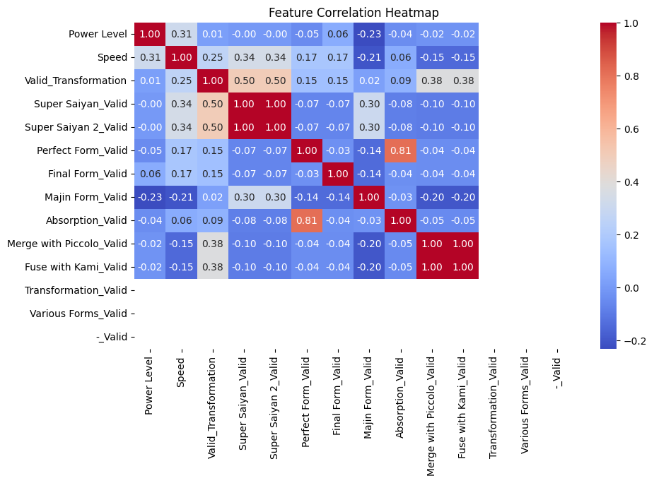

```python
import seaborn as sns
import matplotlib.pyplot as plt

plt.figure(figsize=(10,6))
sns.heatmap(data.corr(), annot=True, cmap="coolwarm", fmt=".2f")
plt.title("Feature Correlation Heatmap")
plt.show()
```

#### Implement PCA

```python
from sklearn.decomposition import PCA
import pandas as pd

n = data_scaled.shape[1]

# Standard PCA
pca = PCA(n_components = n, random_state = 1)
data_pca = pd.DataFrame(pca.fit_transform(data_scaled))
exp_var = pca.explained_variance_ratio_
#data_pca
```

```python
data_pca.shape
```

```
(68, 14)
```

```python
exp_var
```

```
array([3.34191802e-01, 2.74241905e-01, 1.61716533e-01, 8.15078891e-02,
       6.20208801e-02, 4.11625441e-02, 2.09795287e-02, 1.89694035e-02,
       5.20951482e-03, 8.11174850e-32, 2.48857344e-34, 6.97314085e-35,
       8.01449026e-63, 3.32562716e-64])
```

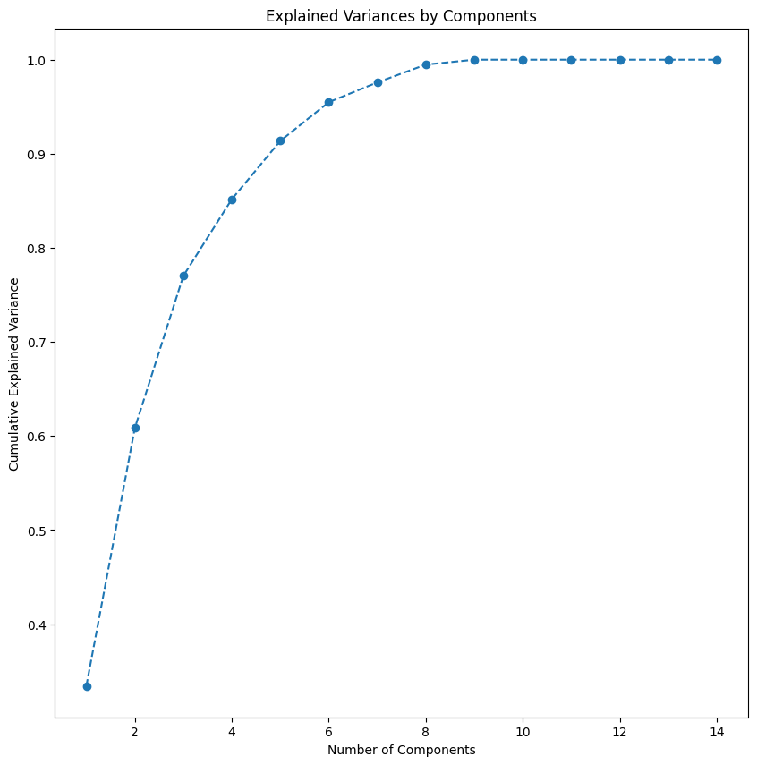

```python
# Plot the cumulative explained variance
plt.figure(figsize=(10, 10))
plt.plot(range(1, len(pca.explained_variance_ratio_) + 1),
         pca.explained_variance_ratio_.cumsum(),
         marker='o', linestyle='--')


plt.title("Explained Variances by Components")
plt.xlabel("Number of Components")
plt.ylabel("Cumulative Explained Variance")
plt.show()
```

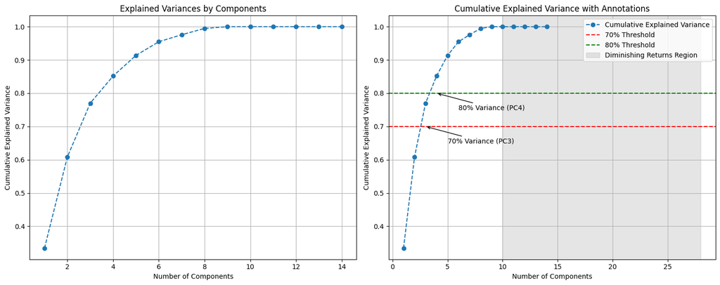

```python
# Apply PCA
pca = PCA(n_components=14)  # Adjust n_components based on your dataset
data_pca = pca.fit_transform(data_scaled)  # Fit PCA

# Ensure explained_variance_ratio_ exists
explained_variance = pca.explained_variance_ratio_

# Define components range
components = np.arange(1, len(explained_variance) + 1)

# Find number of components needed for 70% and 80% variance
n_components_70 = np.argmax(np.cumsum(explained_variance) >= 0.70) + 1
n_components_80 = np.argmax(np.cumsum(explained_variance) >= 0.80) + 1

# Setup for side-by-side plots
fig, axes = plt.subplots(1, 2, figsize=(15, 6))

# Plot 1: Explained Variances by Components
axes[0].plot(components, np.cumsum(explained_variance), marker='o', linestyle='--')
axes[0].set_title("Explained Variances by Components")
axes[0].set_xlabel("Number of Components")
axes[0].set_ylabel("Cumulative Explained Variance")
axes[0].grid(True)

# Plot 2: Cumulative Variance with Annotations
axes[1].plot(components, np.cumsum(explained_variance), marker='o', linestyle='--', label="Cumulative Explained Variance")
axes[1].axhline(0.7, color='red', linestyle='--', label="70% Threshold")
axes[1].axhline(0.8, color='green', linestyle='--', label="80% Threshold")

# Annotate important points
axes[1].annotate(f"70% Variance (PC{n_components_70})", xy=(n_components_70, 0.7), xytext=(n_components_70 + 2, 0.65),
                 arrowprops=dict(facecolor='red', arrowstyle='->'), fontsize=10)

axes[1].annotate(f"80% Variance (PC{n_components_80})", xy=(n_components_80, 0.8), xytext=(n_components_80 + 2, 0.75),
                 arrowprops=dict(facecolor='green', arrowstyle='->'), fontsize=10)

# Highlight the diminishing returns region
axes[1].axvspan(10, 28, color='gray', alpha=0.2, label="Diminishing Returns Region")

# Customize second plot
axes[1].set_title("Cumulative Explained Variance with Annotations")
axes[1].set_xlabel("Number of Components")
axes[1].set_ylabel("Cumulative Explained Variance")
axes[1].legend()
axes[1].grid(True)

# Adjust layout and display
plt.tight_layout()
plt.show()
```

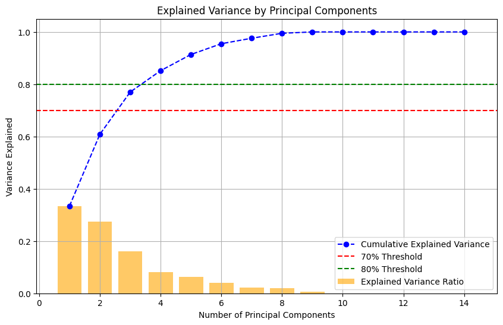

```python
# Assuming exp_var contains the explained variance ratio
components = np.arange(1, len(exp_var) + 1)  # Create an array from 1 to the number of components
cumulative_variance = np.cumsum(exp_var)  # Cumulative sum of the explained variance

# Plot cumulative explained variance
plt.figure(figsize=(10, 6))
plt.plot(components, cumulative_variance, marker='o', linestyle='--', color='b', label='Cumulative Explained Variance')
plt.bar(components, exp_var, alpha=0.6, color='orange', label='Explained Variance Ratio')

# Add titles and labels
plt.title("Explained Variance by Principal Components")
plt.xlabel("Number of Principal Components")
plt.ylabel("Variance Explained")
plt.axhline(y=0.7, color='r', linestyle='--', label='70% Threshold')
plt.axhline(y=0.8, color='g', linestyle='--', label='80% Threshold')

# Add a legend and grid
plt.legend()
plt.grid(True)
plt.show()
```

```python
# Finding the least number of components that can explain more than 70%, 80%, 90%, and 95% variance
variance_thresholds = [0.70, 0.80, 0.90, 0.95]  # Variance thresholds to check
threshold_results = {}  # Dictionary to store results

cumulative_sum = 0

for ix, var in enumerate(exp_var):
    cumulative_sum += var  # Accumulate explained variance

    for threshold in variance_thresholds:
        if threshold not in threshold_results and cumulative_sum > threshold:
            threshold_results[threshold] = ix + 1  # Store the number of components

# Display results
for threshold, components in threshold_results.items():
    print(f"✅ Number of PCs that explain at least {int(threshold * 100)}% variance: {components}")
```

```
✅ Number of PCs that explain at least 70% variance: 3
✅ Number of PCs that explain at least 80% variance: 4
✅ Number of PCs that explain at least 90% variance: 5
✅ Number of PCs that explain at least 95% variance: 6
```

- **4 components**: retain most information while reducing dimensions (80% variance) seem to be a sweet spot
- 5 - 6 components: better accuracy with slightly more features, (90-95%) are a solid choice
- 6 or More: minimal value due to diminishing returns

#### Elbow Method

```
Number of Clusters: 1 	Average Distortion: 10.104529166913604
Number of Clusters: 2 	Average Distortion: 8.475988683069394
Number of Clusters: 3 	Average Distortion: 6.445628202863876
Number of Clusters: 4 	Average Distortion: 5.049541172735307
Number of Clusters: 5 	Average Distortion: 4.071931254686435
Number of Clusters: 6 	Average Distortion: 3.624847768561273
Number of Clusters: 7 	Average Distortion: 3.1771988504471684
Number of Clusters: 8 	Average Distortion: 3.1245451554155452
Number of Clusters: 9 	Average Distortion: 2.9787794091623034
Number of Clusters: 10 	Average Distortion: 2.638878635905672
Number of Clusters: 11 	Average Distortion: 2.2547617996929907
Number of Clusters: 12 	Average Distortion: 1.891016465431668
Number of Clusters: 13 	Average Distortion: 1.7377004641778429
Number of Clusters: 14 	Average Distortion: 1.48617933137269
```

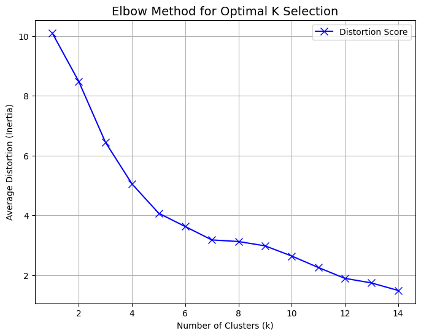

```python
from sklearn.cluster import KMeans
from scipy.spatial.distance import cdist

# Define range of clusters
clusters = range(1, 15)
mean_distortions = []

# Apply K-Means for different cluster numbers
for k in clusters:
    model = KMeans(n_clusters=k, random_state=1, n_init="auto")
    model.fit(data_scaled)  # Fit on PCA-transformed data

    # Calculate distortion (Inertia / Average Distance)
    distortion = np.sum(np.min(cdist(data_scaled, model.cluster_centers_, "euclidean"), axis=1)) / data_pca.shape[0]
    mean_distortions.append(distortion)

    print(f"Number of Clusters: {k} \tAverage Distortion: {distortion}")

# Plot Elbow Curve
plt.figure(figsize=(8, 6))
plt.plot(clusters, mean_distortions, "bx-", markersize=8, label="Distortion Score")

# Labels and title
plt.xlabel("Number of Clusters (k)")
plt.ylabel("Average Distortion (Inertia)")
plt.title("Elbow Method for Optimal K Selection", fontsize=14)
plt.legend()
plt.grid(True)
plt.show()
```

- No clear elbow

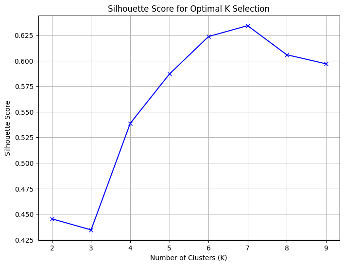

```python
from sklearn.metrics import silhouette_score

# Empty dictionary to store silhouette scores
sc = {}

# Iterate over a range of K values and compute silhouette score
for k in range(2, 10):
    kmeans = KMeans(n_clusters=k, random_state=1).fit(data_pca)  # Use PCA-transformed data
    labels = kmeans.labels_  # Get cluster labels

    # Compute silhouette score
    sc[k] = silhouette_score(data_pca, labels)

# Plot Silhouette Score for different K values
plt.figure(figsize=(8, 6))
plt.plot(list(sc.keys()), list(sc.values()), 'bx-')

plt.xlabel("Number of Clusters (K)")
plt.ylabel("Silhouette Score")
plt.title("Silhouette Score for Optimal K Selection")
plt.grid(True)
plt.show()
```

```python
# Making a new dataframe with first 5 principal components as columns and original features as indices
cols = ['PC1', 'PC2', 'PC3']

pc1 = pd.DataFrame(np.round(pca1.components_.T[:, 0:3], 2), index = data_scaled.columns, columns = cols)
pc1
```

[output not shown]

|  | PC1 | PC2 | PC3 |
| --- | --- | --- | --- |
| Power Level | 0.06 | -0.14 | -0.02 |
| Speed | 0.50 | -0.51 | -0.46 |
| Valid_Transformation | 0.41 | -0.10 | 0.57 |
| Super Saiyan_Valid | 0.51 | 0.12 | 0.06 |
| Super Saiyan 2_Valid | 0.51 | 0.12 | 0.06 |
| Perfect Form_Valid | 0.01 | -0.07 | -0.01 |
| Final Form_Valid | 0.01 | -0.07 | -0.01 |
| Majin Form_Valid | 0.23 | 0.81 | -0.15 |
| Absorption_Valid | 0.00 | -0.04 | -0.01 |
| Merge with Piccolo_Valid | -0.03 | -0.08 | 0.46 |
| Fuse with Kami_Valid | -0.03 | -0.08 | 0.46 |
| Transformation_Valid | 0.00 | -0.00 | 0.00 |
| Various Forms_Valid | 0.00 | -0.00 | 0.00 |
| -_Valid | 0.00 | -0.00 | 0.00 |

```python
def color_high(val):

    if val < -0.25:                     # You can decide any value as per your understanding
        return 'background: pink'

    elif val > 0.25:
        return 'background: skyblue'

pc1.style.map(color_high)
```

|  | PC1 | PC2 | PC3 |
| --- | --- | --- | --- |
| Power Level | 0.060000 | -0.140000 | -0.020000 |
| Speed | 0.500000 | -0.510000 | -0.460000 |
| Valid_Transformation | 0.410000 | -0.100000 | 0.570000 |
| Super Saiyan_Valid | 0.510000 | 0.120000 | 0.060000 |
| Super Saiyan 2_Valid | 0.510000 | 0.120000 | 0.060000 |
| Perfect Form_Valid | 0.010000 | -0.070000 | -0.010000 |
| Final Form_Valid | 0.010000 | -0.070000 | -0.010000 |
| Majin Form_Valid | 0.230000 | 0.810000 | -0.150000 |
| Absorption_Valid | 0.000000 | -0.040000 | -0.010000 |
| Merge with Piccolo_Valid | -0.030000 | -0.080000 | 0.460000 |
| Fuse with Kami_Valid | -0.030000 | -0.080000 | 0.460000 |
| Transformation_Valid | 0.000000 | -0.000000 | 0.000000 |
| Various Forms_Valid | 0.000000 | -0.000000 | 0.000000 |
| -_Valid | 0.000000 | -0.000000 | 0.000000 |

Blue Cells:

- Indicate strong positive contributions of the original features to the principal components.
- A high positive value means that a feature strongly influences that particular principal component in a positive direction.

Pink Cells:

- Indicate strong negative contributions. A high negative value means that a feature strongly influences the principal component in the opposite direction.

Interpretation:

- If a feature has a high positive loading (blue), it plays a significant role in defining that principal component.
- If a feature has a high negative loading (pink), it also plays a significant role but in the opposite direction.

```python
pc1.shape
```

```
(14, 3)
```

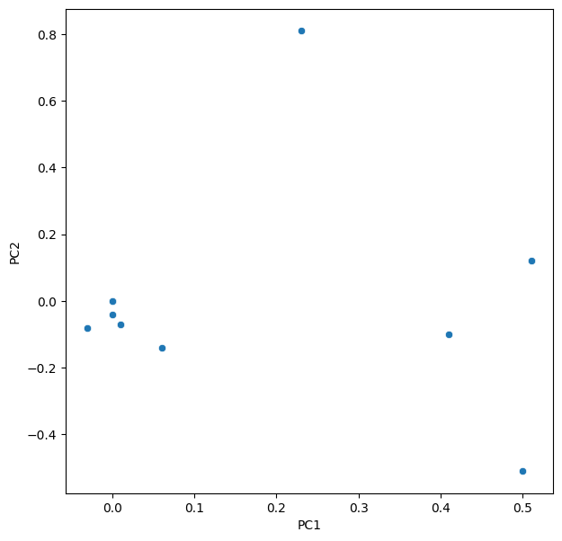

```python
plt.figure(figsize = (7,7))

sns.scatterplot(x = pc1['PC1'], y = pc1['PC2'])

plt.xlabel("PC1")

plt.ylabel("PC2")

plt.show()
```

### t-SNE

```python
from sklearn.manifold import TSNE

# Fitting t-SNE with number of components equal to 2
tsne = TSNE(n_components = 2, random_state = 1)

data_tsne = tsne.fit_transform(data_scaled)
```

2D Visualization

```python
# Converting the embeddings to a dataframe
data_tsne = pd.DataFrame(data_tsne, columns = ['X1', 'X2'])
```

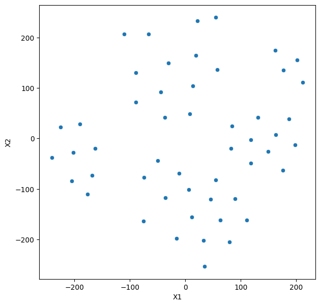

```python
# Scatter plot for two components
plt.figure(figsize = (7,7))

sns.scatterplot(x = 'X1', y = 'X2', data = data_tsne)

plt.show()
```

3D Visualization

```python
# Fitting t-SNE with number of components equal to 3
tsne = TSNE(n_components = 3, random_state = 1)

data_tsne = tsne.fit_transform(data_scaled)
```

```python
data_tsne = pd.DataFrame(data_tsne, columns = ['X1', 'X2', 'X3'])
```

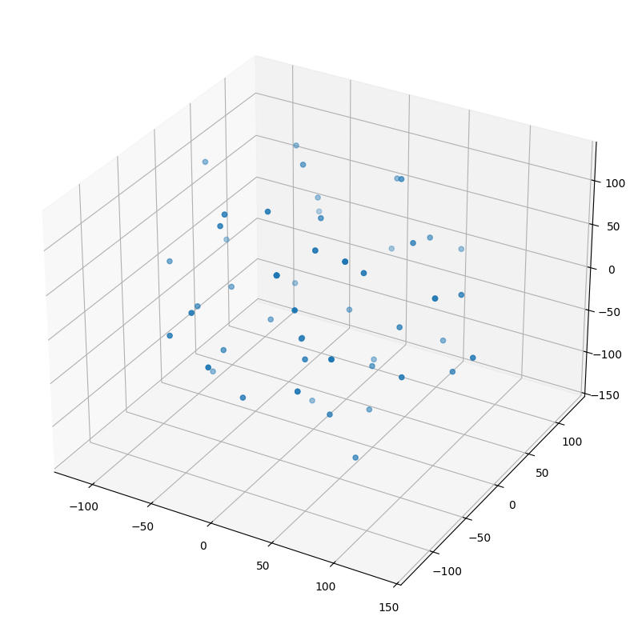

```python
# Scatter plot for all three components
fig = plt.figure(figsize = (10, 10))

ax = fig.add_subplot(111, projection = '3d')

x = data_tsne['X1']

y = data_tsne['X2']

z = data_tsne['X3']

ax.scatter(x, y, z)

plt.show()
```

Perplexity

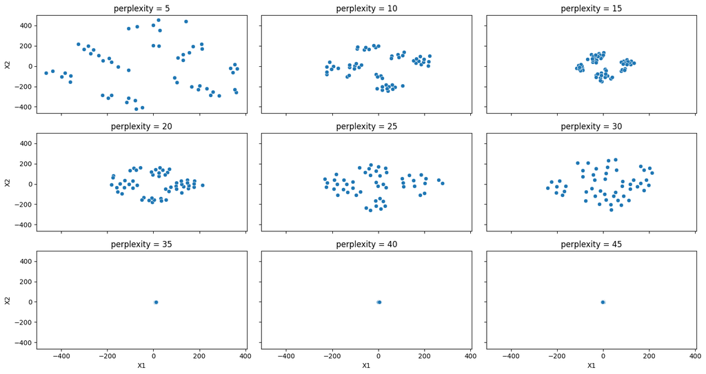

```python
fig, axes = plt.subplots(3,3, sharex=True, sharey=True, figsize=(15,8))

i = 5
for x in range(3):
  for y in range(3):
    # Initialize TSNE
    tsne = TSNE(n_components = 2, random_state = 1, perplexity = i)

    # Train and apply the model
    data_tsne = tsne.fit_transform(data_scaled)

    # Convert the output to a pandas DataFrame
    data_tsne = pd.DataFrame(data_tsne)

    # Rename the columns
    data_tsne.columns = ['X1', 'X2']

    sns.scatterplot(x = 'X1', y = 'X2', data = data_tsne, ax=axes[x,y])

    # Set title
    axes[x,y].set_title("perplexity = {}".format(i))

    i += 5

plt.tight_layout()
```

- perplexity 15 showing about 4 clusters

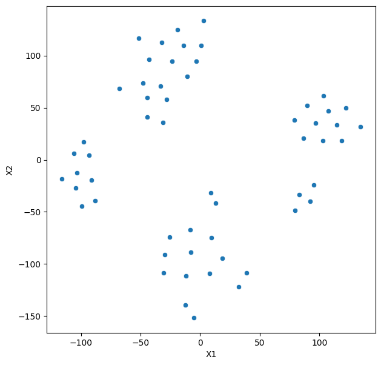

```python
# Fitting t-SNE with number of components equal to 2
tsne = TSNE(n_components = 2, random_state = 1, perplexity = 15)

data_tsne = tsne.fit_transform(data_scaled)

# Converting the embeddings to a dataframe
data_tsne = pd.DataFrame(data_tsne, columns = ["X1", "X2"])

# Scatter plot for two components
plt.figure(figsize = (7, 7))

sns.scatterplot(x = 'X1', y = 'X2', data = data_tsne)

plt.show()
```